# Modeling and prediction for movies

## Setup

### Load packages

```r
library(ggplot2)
library(dplyr)
library(statsr)
```

### Load data

Make sure your data and R Markdown files are in the same directory. When loaded your data file will be called `movies`. Delete this note when before you submit your work.

```r
#load("movies.Rdata")
```

```r
load("movies.gz")
movies
```

```
## # A tibble: 651 x 32
##    title title_type genre runtime mpaa_rating studio thtr_rel_year
##    <chr> <fct>      <fct>   <dbl> <fct>       <fct>          <dbl>
##  1 Fill~ Feature F~ Drama      80 R           Indom~          2013
##  2 The ~ Feature F~ Drama     101 PG-13       Warne~          2001
##  3 Wait~ Feature F~ Come~      84 R           Sony ~          1996
##  4 The ~ Feature F~ Drama     139 PG          Colum~          1993
##  5 Male~ Feature F~ Horr~      90 R           Ancho~          2004
##  6 Old ~ Documenta~ Docu~      78 Unrated     Shcal~          2009
##  7 Lady~ Feature F~ Drama     142 PG-13       Param~          1986
##  8 Mad ~ Feature F~ Drama      93 R           MGM/U~          1996
##  9 Beau~ Documenta~ Docu~      88 Unrated     Indep~          2012
## 10 The ~ Feature F~ Drama     119 Unrated     IFC F~          2012
## # ... with 641 more rows, and 25 more variables: thtr_rel_month <dbl>,
## #   thtr_rel_day <dbl>, dvd_rel_year <dbl>, dvd_rel_month <dbl>,
## #   dvd_rel_day <dbl>, imdb_rating <dbl>, imdb_num_votes <int>,
## #   critics_rating <fct>, critics_score <dbl>, audience_rating <fct>,
## #   audience_score <dbl>, best_pic_nom <fct>, best_pic_win <fct>,
## #   best_actor_win <fct>, best_actress_win <fct>, best_dir_win <fct>,
## #   top200_box <fct>, director <chr>, actor1 <chr>, actor2 <chr>,
## #   actor3 <chr>, actor4 <chr>, actor5 <chr>, imdb_url <chr>, rt_url <chr>
```

https://en.wikipedia.org/wiki/Paramount_Pictures https://en.wikipedia.org/wiki/Rotten_Tomatoes https://en.wikipedia.org/wiki/IMDb * * *

## Part 1: Data

Paramount Pictures is a legend within the United States as the second oldest film studio. As a data scientist for Paramount Pictures we help to identify trends and insights from publicly gathered data to provide the film studio a competitive edge.

This dataset, at first glance, appears to be a great fit to be used for a prediction model. The dataset was gathered using random sampling so there should be a random representation of varying movie types with some of them being well received movies and others not being so well received by audiences. This is important as it provides a good opportunity of movies that fit what we are trying to predict. A large sample of 651 movies should be large enough to avoid bias in the data collection which also provides a list of independent observations. With over 30 variables that are representative of the movies and their ratings from Rotten Tomatoes and IMDB should be expansive enough to help us pick up on a variable or two that will be significant predictors of our predicted response.

## Part 2: Research question

The first step is to define a single response variable of movie popularity. This will allow us to investigate assocations between movie attributes and the movie popularity. From there we can see which variables, if any, are significant predictors of a movie’s popularity.

## Part 3: Exploratory data analysis

Before proceeding with modelling, a response variable needs to be obtained. There are four variables that could be combined to generate an overall moview popularity score. Those four variables are: the IMDB rating, Rotten Tomatoes critics score or rating, Rotten Tomatoes audience score or rating and whether the movie was in the Top 200 Box Office list. Each variable addresses popularity on different circumstances but all can help contribute to a movie selling well and thus becoming popular. Let us take a closer look at these four competing variables for defining popularity.

Consulting the Wikepedia site for Rotten Tomatoes critic score, it appears that the critic’s score must be greater than 60 to be considered ‘Fresh’ and to be eligible as ‘Certified Fresh’ it must have a score of 70 or higher and meet the criteria for number of reviews by top critics. The first plot displays the distribution of critic’s scores which tells us that critic’s are rather critical with their rating since the distribution is rather constant. Not every critic gives high ratings. The second plot demonstrates how a movie’s score must meet the requirements to be ‘Certified Fresh’ (1.0), ‘Fresh’ (2.0) or ‘Rotten’ (3.0). This is a great visualization of the rating requirements incorporating the thresholds described above and the number of votes by top critics receive the distingued rating of ‘Certified Fresh’ (1.0).

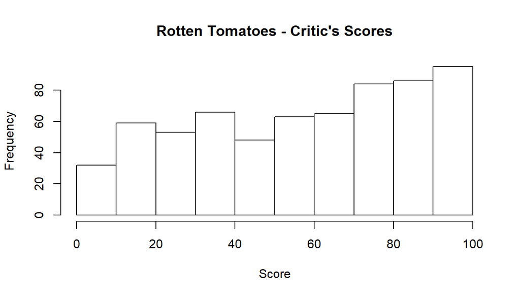

```r
hist(movies$critics_score, xlab = "Score", main = "Rotten Tomatoes - Critic's Scores")
```

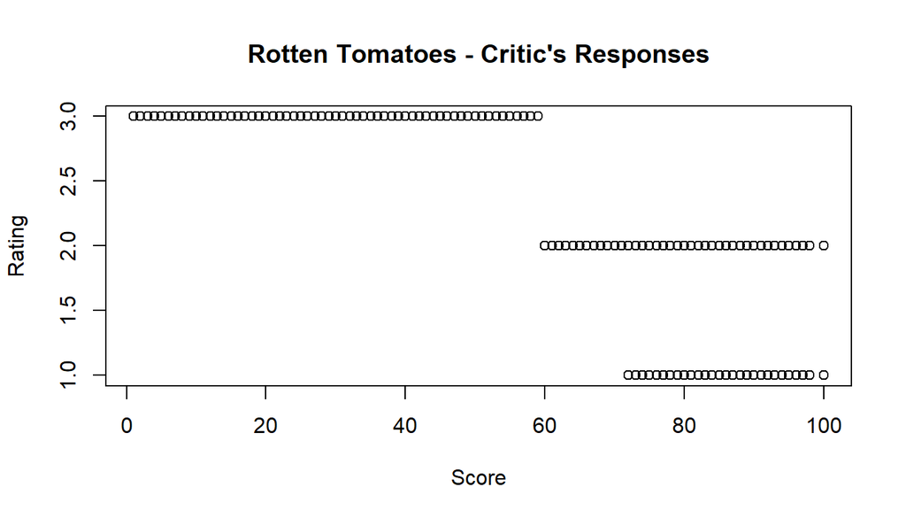

```r
plot(movies$critics_score, movies$critics_rating, xlab = "Score", ylab = "Rating", main = "Rotten Tomatoes - Critic's Responses")
```

A similar calculation is used by Rotten Tomatoes to determine the audience rating of ‘Upright’. The first plot displays the audience’s scores which displays more of a skew than the critic’s scores. This tells us that the audience is more lenient and likely to give a favorable score. The second plot demonstrates the relationship between the audience score and the audience rating of ‘Spilled’ (1.0) and ‘Upright’ (2.0). This is a visualization of the criteria for a movie to have an audience score of 60 or greater to be deemed an ‘Upright’ rating.

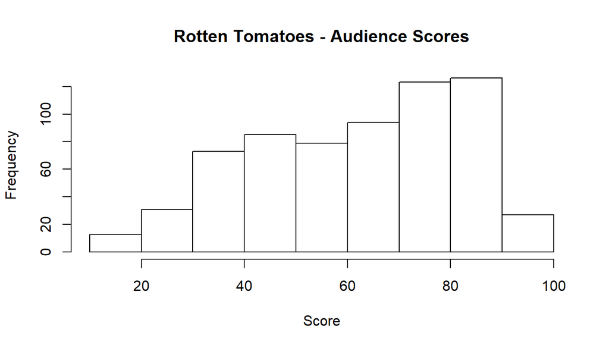

```r
hist(movies$audience_score, xlab = "Score", main = "Rotten Tomatoes - Audience Scores")
```

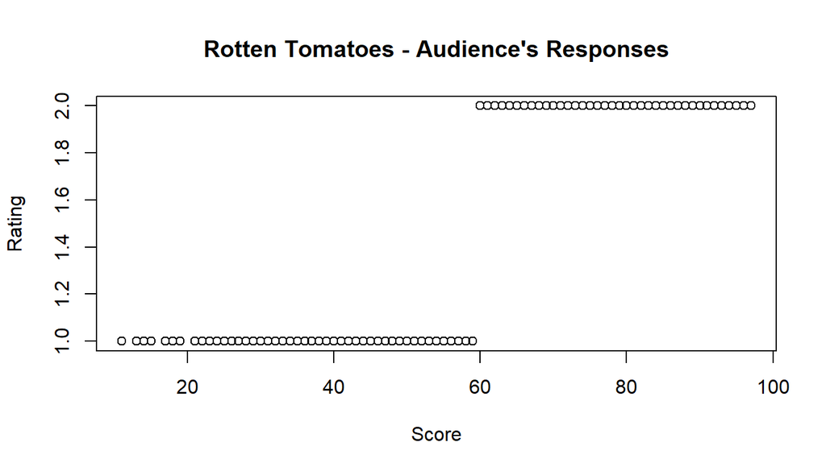

```r
plot(movies$audience_score, movies$audience_rating, xlab = "Score", ylab = "Rating", main = "Rotten Tomatoes - Audience's Responses")
```

The IMDB Top Rated Movies list encompasses movies with an IMDB rating of greater than 8.0 and more than 25,000 votes. We can tell by the plots provided that few movies earn a rating of 8.0 or higher and the majority of movies that meet that rating tend to have a considerable amount of votes as well. The first plot provides the distribution of IMDB ratings which are even more skewed than the Rotten Tomatoes’ audience rating distribution. This tells us that IMDB is very likely to provide a favorable rating. The second plot demonstrates the relationship between IMDB ratings and the number of voters. This is a visualization of how movies with higher ratings also tend to have more voters.

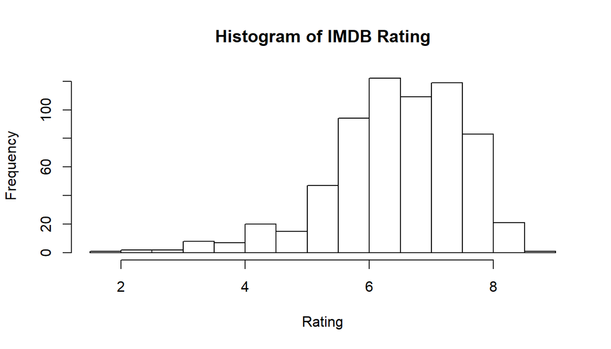

```r
hist(movies$imdb_rating, main = "Histogram of IMDB Rating", xlab = "Rating")
```

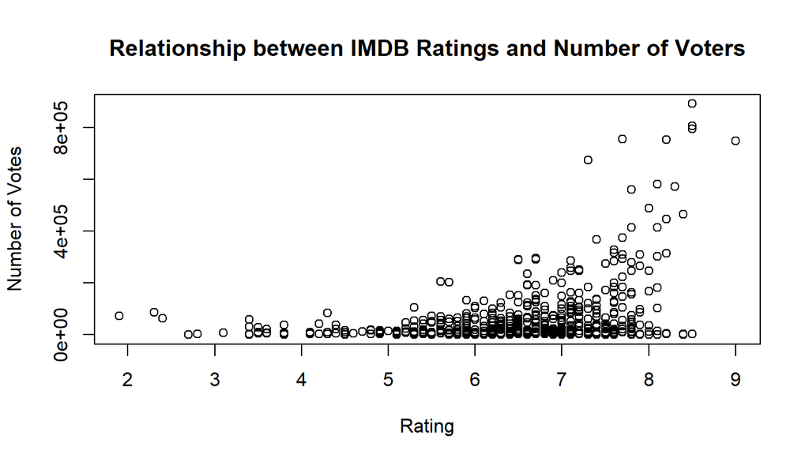

```r
plot(movies$imdb_rating, movies$imdb_num_votes, xlab = "Rating", ylab = "Number of Votes", main = "Relationship between IMDB Ratings and Number of Voters")
```

It is fair to assume that if a movie tends to be popular then it will be a Top Box Office movie. Due to this close assocation we will exclude top box office indicator from the model to avoid multi-collinearity which are variables that have a close association with each other as it provides unnecessary bias to the model.

With the three remaining indicators of popularity, we will create a new variable summarizing all three. This calculated column takes the Rotten Tomatoes’ critic score and audience score and divide them by 10 to get them on the same ten point scale as the IMDB rating. Then it will add all three scores together and divide that by three to get the average rating on a ten point scale. We will consider a score of 8.0 or higher to be popular among either Rotten Tomatoes’ critics, Rotten Tomatoes’ audience or IMDB’s voters. The histogram plot provides the distribution of this new popularity rating which is on a ten point scale with a rather constant distribution between 5.0 and 9.0 and a drastic decline in ratings of less than 5.0 and very few ratings above 9.0. This is a good summary rating of the three individual ratings that were reviewed above which makes this a fit rating to predict to.

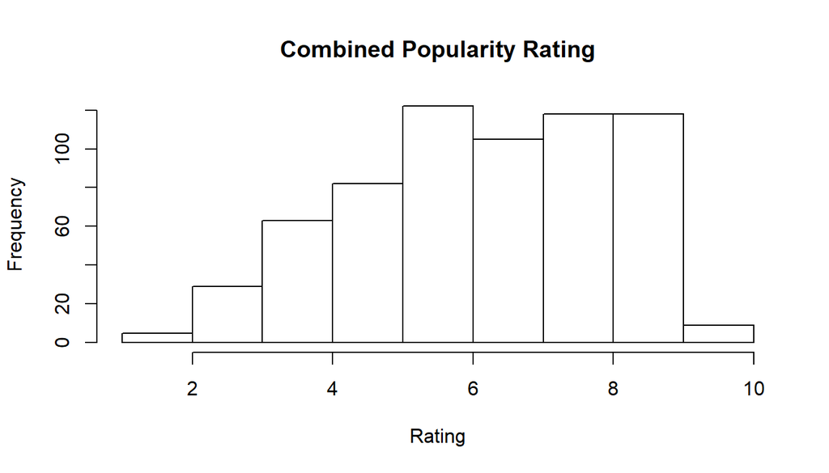

```r
movies$pop_rating <- ((movies$imdb_rating + (movies$critics_score/ 10) + (movies$audience_score / 10)) / 3)

hist(movies$pop_rating, xlab = "Rating", main = "Combined Popularity Rating")
```

Turning now to the explanatory variables, there are some items to address. The variables related to how many main actors/actresses currently list specific names of who are the actors/actresses. This is difficult to incorporate into a linear model as there are many different available values. This can be corrected into a count of how many main actors/actresses that were in each movie. Below is a distribution of this newly created variable, actor_cnt. The majority of movies listed in the dataset have at least five main actors/actresses.

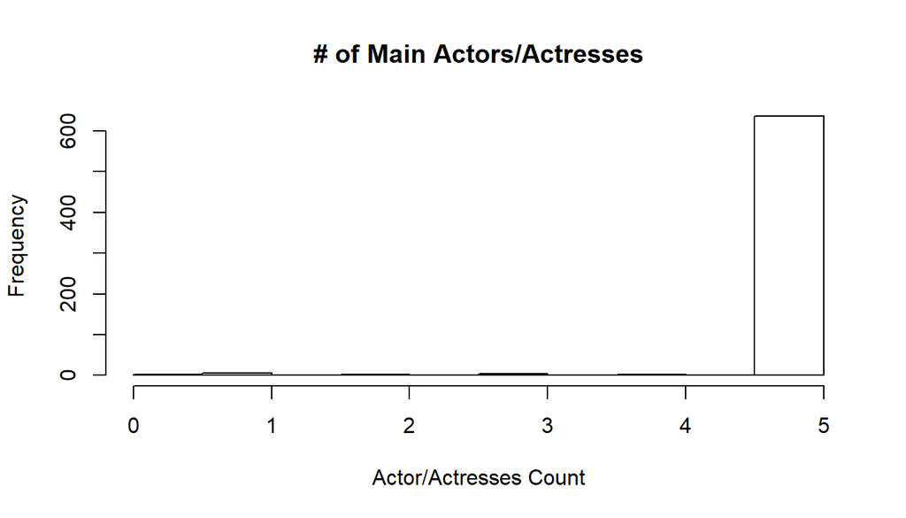

```r
movies$actor1b <- ifelse(is.na(movies$actor1),0,1)
movies$actor2b <- ifelse(is.na(movies$actor2),0,1)
movies$actor3b <- ifelse(is.na(movies$actor3),0,1)
movies$actor4b <- ifelse(is.na(movies$actor4),0,1)
movies$actor5b <- ifelse(is.na(movies$actor5),0,1)
movies$actor_cnt <- rowSums(movies[,c("actor1b","actor2b","actor3b","actor4b","actor5b")])

hist(movies$actor_cnt, main = "# of Main Actors/Actresses", xlab = "Actor/Actresses Count")
```

There are two variables related to the director of the movie; the name of the director and whether the director has won for best director. In an effort to avoid multi-collinearity we will exclude the name of the director and instead utilize the variable of whether or not the director has won for best director. This is most likely of more interest to someone watching a new movie as they may prefer movies that were directed by someone with a past history of success. For our dataset, the plot below lets us know that not many movies were directed by someone who won for ‘Best Director’.

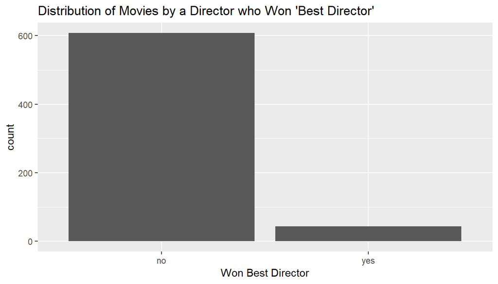

```r
ggplot(data.frame(movies), aes(x=best_dir_win)) + geom_bar() + xlab("Won Best Director") + ggtitle("Distribution of Movies by a Director who Won 'Best Director'")
```

We have another occurrence of potential multi-collinearity between variables of movies nominated for best picture versus those that won for best picture. Movies that win for best picture must also be nominated to win. In this case we will exclude the variable for whether the movie won for best picture and only untilize whether the movie was nominated. The plots below tell us, for our dataset, that not many movies were nominated for best picture and even fewer won for best picture.

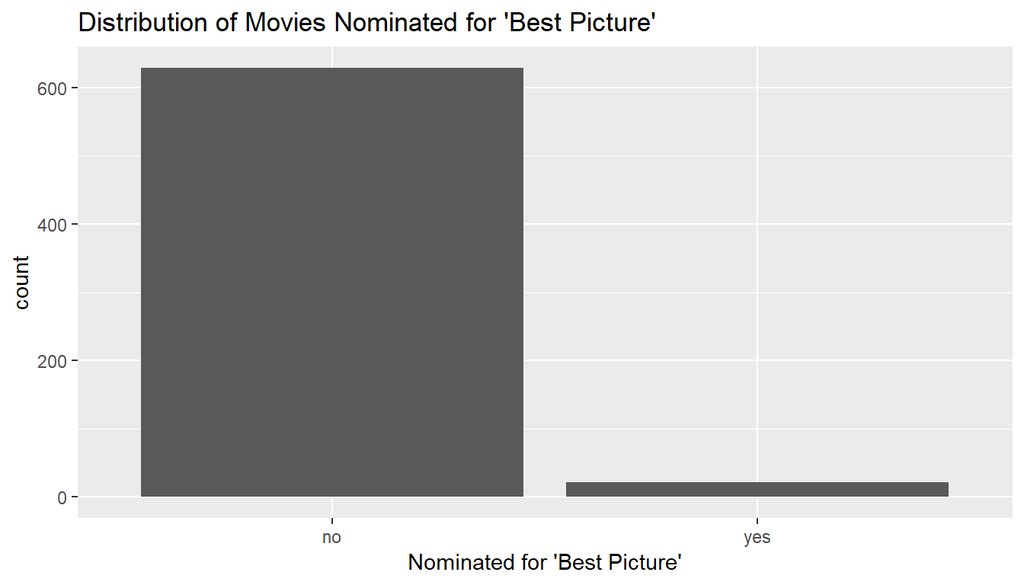

```r
ggplot(data.frame(movies), aes(x=best_pic_nom)) + geom_bar() + xlab("Nominated for 'Best Picture'") + ggtitle("Distribution of Movies Nominated for 'Best Picture'")
```

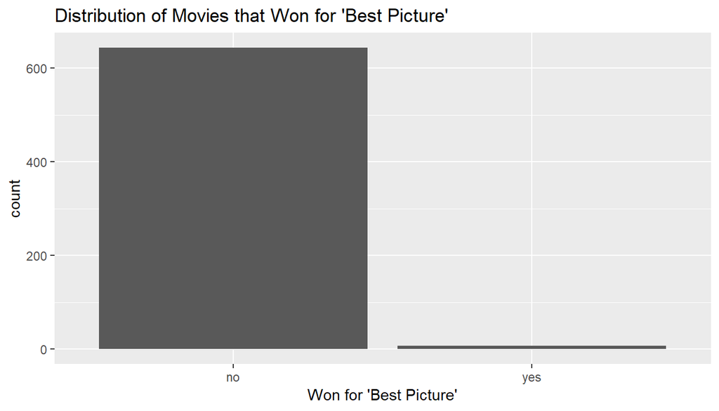

```r
ggplot(data.frame(movies), aes(x=best_pic_win)) + geom_bar() + xlab("Won for 'Best Picture'") + ggtitle("Distribution of Movies that Won for 'Best Picture'")
```

Lastly, variables with more than two levels need to be converted into binary variables. To do this, each level of the categorical variable becomes its own variable. As a demonstration, the variable title type returns whether the movie was a feature film, documentary or a TV movie. The end result would be a new variable of whether the movie was a feature film or not, another variable of whether the movie was a documentary or not and another variable of whether the movie was a TV movie or not. This approach is taken for the title type variable, the genre of the movie and the MPAA rating variable.

```r
movies$genre_action = ifelse(movies$genre == "Action & Adventure",1,0)
movies$genre_animation = ifelse(movies$genre == "Animation",1,0)
movies$genre_art = ifelse(movies$genre == "Art House & International",1,0)
movies$genre_comedy = ifelse(movies$genre == "Comedy",1,0)
movies$genre_documentary = ifelse(movies$genre == "Drama",1,0)
movies$genre_drama = ifelse(movies$genre == "Drama",1,0)
movies$genre_horror = ifelse(movies$genre == "Horror",1,0)
movies$genre_mystery = ifelse(movies$genre == "Mystery & Suspense",1,0)
movies$genre_other = ifelse(movies$genre == "Other",1,0)
movies$genre_perf = ifelse(movies$genre == "Musical & Performing Arts",1,0)
movies$genre_scifi = ifelse(movies$genre == "Science Fiction & Fantasy",1,0)

movies$type_film = ifelse(movies$title_type == "Feature Film",1,0)
movies$type_docu = ifelse(movies$title_type == "Documentary",1,0)
movies$type_tvmovie = ifelse(movies$title_type == "TV Movie",1,0)

movies$mpaa_r = ifelse(movies$mpaa_rating == "R",1,0)
movies$mpaa_pg13 = ifelse(movies$mpaa_rating == "PG-13",1,0)
movies$mpaa_pg = ifelse(movies$mpaa_rating == "PG",1,0)
movies$mpaa_unrated = ifelse(movies$mpaa_rating == "Unrated",1,0)
movies$mpaa_g = ifelse(movies$mpaa_rating == "G",1,0)
movies$mpaa_nc17 = ifelse(movies$mpaa_rating == "NC-17",1,0)
```

## Part 4: Modeling

With the dataset cleaned up we are ready to turn to constructing the linear model. We will use the calculated popularity rating variable as the response variable since want to predict the popularity rating.

The explanatory variables will be a mix of raw variables from the dataset and others that were calculated during our exploratory analysis; a variable representing each level of title type, genre and MPAA rating as well as runtime, year, month and day that the movie was released to theather, the year, month and day the movie was released to DVD, whether the movie was nominated for ‘Best Picture’, whether an actor in the movie won ‘Best Actor’, whether an actress in the movie won ‘Best Actress’, whether the director had won for ‘Best Director’, and a count of how many main actors or actresses there were.

I decided to exclude movie title as it is specific to each movie and does not really contain any shared attributes with any other movie. Studio was excluded as there were many values to summarize or bin. ‘Best Picture’ win was excluded as we will be utilizing ‘Best Picture’ nominations instead and the same goes for excluding Top 200 Box Office since this is closely associated with our response variable. Director was excluded as we are leveraging the variable of ‘Best Director’ wins instead. These exclusions are specifcly done to avoid multi-collinearity. The IMDB and Rotten Tomatoes URL’s were excluded for similar reason as the movie title, it does not provide much shared context amongst other movies.

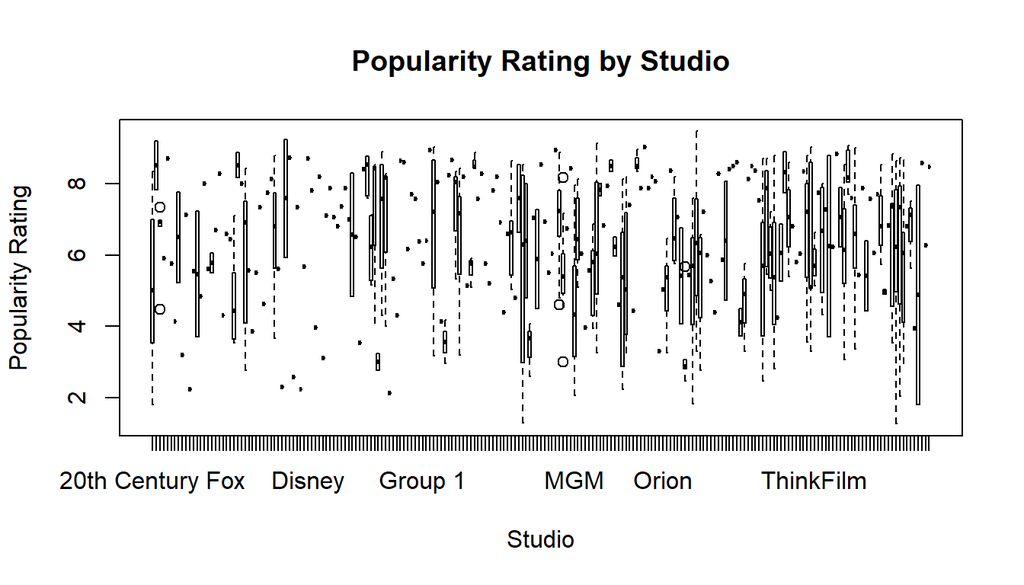

```r
plot(x=movies$studio, y=movies$pop_rating, xlab = "Studio", ylab = "Popularity Rating", main = "Popularity Rating by Studio")
```

Our goal of this model is to identify which are significant predictors of popularity rating. With this in mind, we will choose to use the backwards p-value method for model selection as this places emphasis on identifying significant predictors, whereas, the R^2 method places emphasis on model prediction accuracy.

A total of twenty models were ran until all explanatory variables were significant. Below is a list of the order of variables being removed from the model and the corresponding p-value.

Model 1) All Variables -  
Model 2) actor_cnt 0.94645 Model 3) mpaa_unrated 0.90196 Model 4) mpaa_nc17 0.901965 Model 5) genre_animation 0.88661 Model 6) genre_scifi 0.88661 Model 7) best_actress_win 0.788708 Model 8) thtr_rel_month 0.774942 Model 9) best_actor_win 0.605918 Model 10) genre_mystery 0.56873 Model 11) mpaa_g 0.658211 Model 12) dvd_rel_year 0.499544 Model 13) genre_art 0.456605 Model 14) genre_documentary 0.349155 Model 15) type_film 0.27231 Model 16) type_tvmovie 0.27231 Model 17) dvd_rel_day 0.29492 Model 18) genre_other 0.28126 Model 19) thtr_rel_day 0.211708 Model 20) dvd_rel_month 0.050492

Now that we have statistically significant predictors in the twentieth model, we still need to check for model validity.

```r
lm3.20 = lm(pop_rating~ runtime + thtr_rel_year + best_pic_nom + best_dir_win + genre_comedy + genre_horror + genre_drama + genre_action + genre_perf + type_docu + mpaa_r + mpaa_pg13 + mpaa_pg, data = movies)

summary(lm3.20)
```

```
##
## Call:
## lm(formula = pop_rating ~ runtime + thtr_rel_year + best_pic_nom +
##     best_dir_win + genre_comedy + genre_horror + genre_drama +
##     genre_action + genre_perf + type_docu + mpaa_r + mpaa_pg13 +
##     mpaa_pg, data = movies)
##
## Residuals:
##     Min      1Q  Median      3Q     Max
## -4.5235 -1.0354  0.0843  1.0538  3.5845
##
## Coefficients:
##                  Estimate Std. Error t value Pr(>|t|)
## (Intercept)     31.801365  11.552336   2.753 0.006077 **
## runtime          0.012127   0.003410   3.556 0.000404 ***
## thtr_rel_year   -0.013280   0.005757  -2.307 0.021387 *
## best_pic_nomyes  1.750734   0.340174   5.147 3.54e-07 ***
## best_dir_winyes  0.628928   0.246676   2.550 0.011018 *
## genre_comedy    -0.583751   0.218903  -2.667 0.007854 **
## genre_horror    -0.875635   0.347065  -2.523 0.011880 *
## genre_drama      0.522338   0.166459   3.138 0.001780 **
## genre_action    -0.586845   0.235985  -2.487 0.013145 *
## genre_perf       0.903058   0.451369   2.001 0.045848 *
## type_docu        2.175294   0.270595   8.039 4.43e-15 ***
## mpaa_r          -0.714293   0.230498  -3.099 0.002028 **
## mpaa_pg13       -1.259949   0.256986  -4.903 1.20e-06 ***
## mpaa_pg         -0.798185   0.256458  -3.112 0.001939 **
## ---
## Signif. codes:  0 '***' 0.001 '**' 0.01 '*' 0.05 '.' 0.1 ' ' 1
##
## Residual standard error: 1.498 on 636 degrees of freedom
##   (1 observation deleted due to missingness)
## Multiple R-squared:  0.3394, Adjusted R-squared:  0.3259
## F-statistic: 25.13 on 13 and 636 DF,  p-value: < 2.2e-16
```

The first thing to check is whether there is a linear relationship between the residuals of our model and the corresponding numerical variables. We can check this by plotting the residuals from the model against each numeric variable and expect to see constant variance in the scatterplots. The two numeric variables we have to check are movie runtime and theater release year as the remaining variables are binary. Both plots display constance an either side of residuals being positive as there are to residuals being negative. This tells us that the linear model passes this diagnostic.

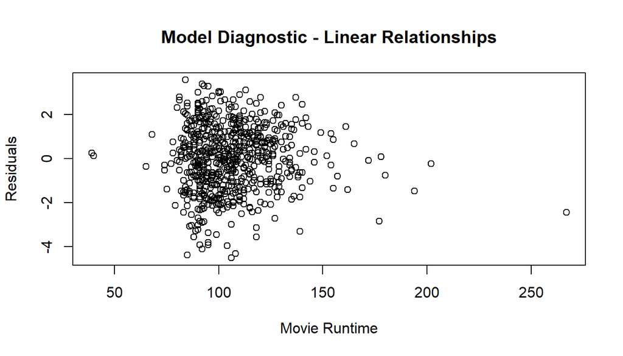

```r
movies3 <- movies[!is.na(movies$runtime),]

plot(lm3.20$residuals ~ movies3$runtime, xlab = "Movie Runtime", ylab = "Residuals", main = "Model Diagnostic - Linear Relationships")
```

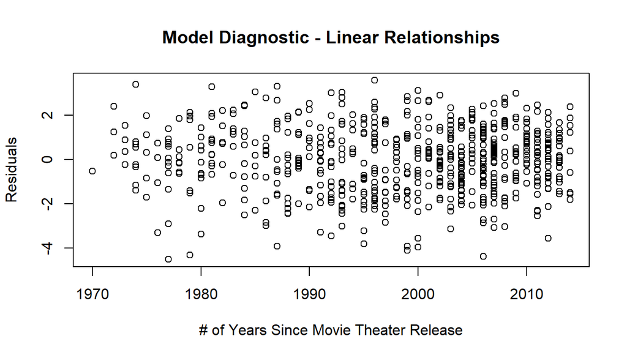

```r
plot(lm3.20$residuals ~ movies3$thtr_rel_year, xlab = "# of Years Since Movie Theater Release", ylab = "Residuals", main = "Model Diagnostic - Linear Relationships")
```

We also need to check if the residuals are nearly normal with a mean of approximately zero. This can be checked by creating a histogram of the residuals with an expectation of a normal distribution. We can also create a QQ Plot and expect the residuals to hover along the linear line of the plot. Both checks are met given the plots below.

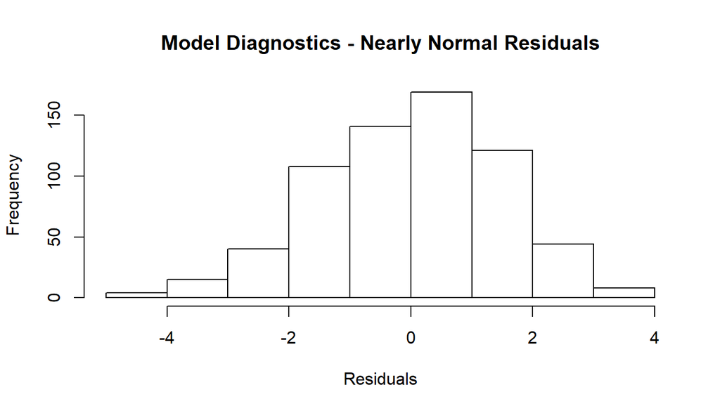

```r
hist(lm3.20$residuals, xlab = "Residuals", main = "Model Diagnostics - Nearly Normal Residuals")
```

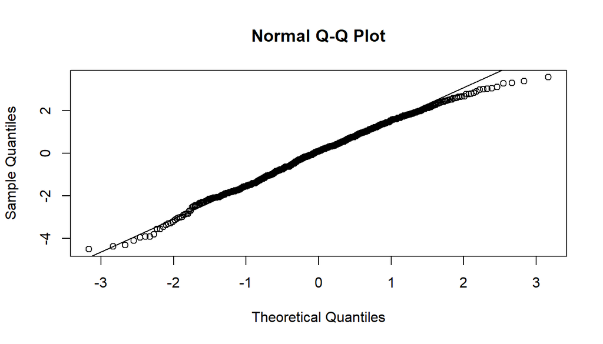

```r
qqnorm(lm3.20$residuals)

qqline(lm3.20$residuals)
```

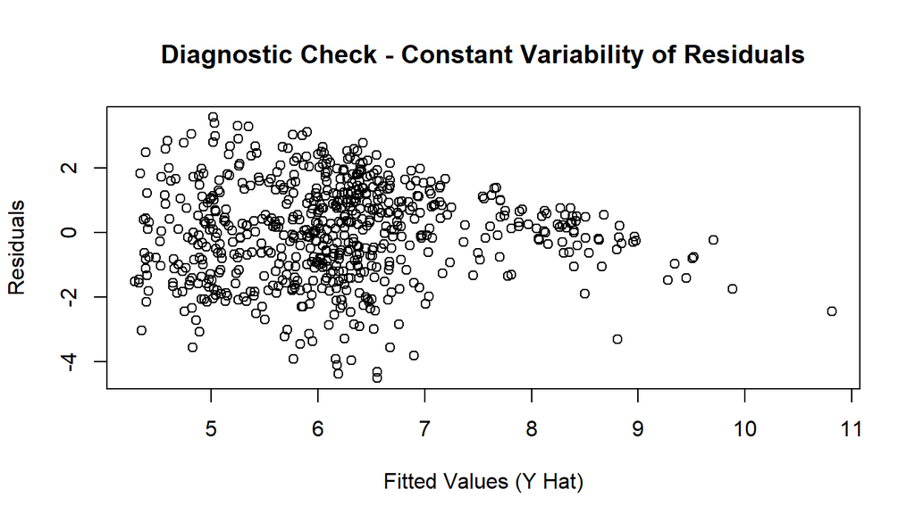

```r
plot(lm3.20$residuals ~ lm3.20$fitted.values, xlab = "Fitted Values (Y Hat)", ylab = "Residuals", main = "Diagnostic Check - Constant Variability of Residuals")
```

The last thing to check is whether the observations are independent. We would suspect this diagnostic to pass because the dataset was randomly selected but we can verify this by plotting the residuals. When we do this, the plot does in fact appear to have constant variance among all observations in our data set because the plot contains no patterns.

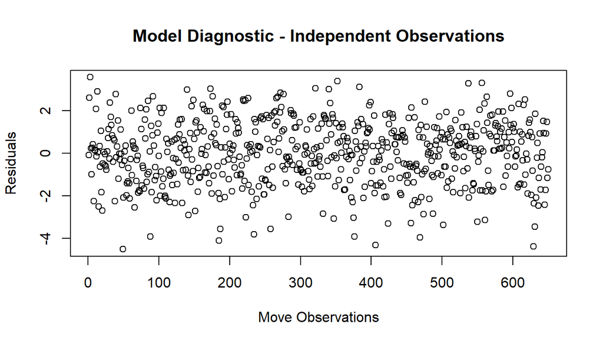

```r
plot(lm3.20$residuals, xlab = "Move Observations", ylab = "Residuals", main = "Model Diagnostic - Independent Observations")
```

Now that we know the model has all significant predictors and is a valid model, we can begin to interpret the coefficients. Starting with the intercept, it is not reasonable to think a movie to not have any of the attributes that were incorporated into the model and, thus, interpreting the intercept would not make sense either.

The explanatory variables tell some of the story. A few of the variables that positively impact popularity rating are documentary type movies, movies that were nominated for ‘Best Picture’, those that have a genre of musical and performing arts and whether the director had won for ‘Best Director’. In particular, compared to movies that are not documentaries, we would expect movies that are documentary to have a popularity rating higher by 2.17, on average, assuming all else constant. Behind that, again, in comparison to movies that are not nominated for ‘Best Picture’, we would expect movies that are nominated for ’Best Picture’to have a popularity rating higher by 1.75, assuming all else constant.

On the other hand, there are associated with a lower popularity rating. Some of these variables are movies that have an MPAA rating of PG-13 and movies that have a horror genre. Compared to movies that are not PG-13, we would expect movies that are PG-13 to have a popularity rating lower by 1.26, on average, assuming all else constant. Similarly, compared to movies that are not horror genre, those that are we would expect to have a popularity rating lower by 0.88, on average, assuming all else constant.

## Part 5: Prediction

https://www.imdb.com/title/tt1386697/?ref_=nv_sr_1 https://www.rottentomatoes.com/m/suicide_squad_2016 https://www.filmsite.org/bestpics.html https://www.filmsite.org/bestdirs2.html

```r
newData = data.frame(x=1, title="Suicide Squad", type_docu=0, best_pic_nom="no", genre_perf=0, best_dir_win="no", genre_drama=0, runtime=123, thtr_rel_year=2016, genre_comedy=0, genre_action=1, mpaa_r=0, mpaa_pg=0, genre_horror=0, mpaa_pg13=1)

prediction_suicide_squad = predict(lm3.20, newData, interval = 'confidence')

prediction_suicide_squad
```

```
##       fit      lwr     upr
## 1 4.67411 4.202539 5.14568
```

## Part 6: Conclusion

It is reassuring that our model met the model diagnostics to be considered a valid model. There is still room for improvement by revisiting the studio that produced the movie. Perhaps with expert opinion there is a way to bin them into more useful groupings. I would also encourage an elaborate brainstorming session or polling an audience of randomly selected movie critics or movie go-ers to prompt them for what they place emphasis on to determine a movie’s popularity. This can lead to incorporating additional variables into the model to improve model accuracy.